# Pitchfork Analysis

Michael Mann

2022-06-17

This is a quick analysis to dive into how pitchfork review scores have changed over time. This is a fascinating dataset becuase you have a large sample size and can account for factors such as author of the review. I am going to analyze how the scores have changed across each genre, how the allocation of reviews for each genre has changed, and finally, how their use of very low scores has shifted.

First, I need to query the database by setting up a connection to the sqlite databse. I can do this with DBI

```r
library(DBI)
library(tidyverse)
pitchfork_db <- dbConnect(RSQLite::SQLite(), "database.sqlite")
```

This is checking for all the tables present in the database

```r
# list all table
dbListTables(pitchfork_db)
```

```
## [1] "artists" "content" "genres"  "labels"  "reviews" "years"
```

Example of listing all of the fields in the reviews table

```r
# list all table
dbListFields(pitchfork_db, "reviews")
```

```
##  [1] "reviewid"       "title"          "artist"         "url"
##  [5] "score"          "best_new_music" "author"         "author_type"
##  [9] "pub_date"       "pub_weekday"    "pub_day"        "pub_month"
## [13] "pub_year"
```

I am creating a SQL query below and saving it to the pitchfork_dataset object. This code joins three separate tables (reviews, artists, and genres) into one dataframe

```r
pitchfork_dataset <-
  dbGetQuery(pitchfork_db,
           "SELECT
              r.reviewid AS reviews_reviewid,
              r.title,
              r.score,
              r.best_new_music,
              r.author,
              r.author_type,
              r.pub_date,
              r.pub_year,
              a.artist,
              a.reviewid AS artists_reviewid,
              g.reviewid AS genres_reviewid,
              g.genre
            FROM reviews r
            LEFT JOIN artists a
            ON r.reviewid = a.reviewid
            LEFT JOIN genres g
            ON r.reviewid = g.reviewid;") %>%
  tibble()  %>% # change to tibble
  select(-artists_reviewid, -genres_reviewid) # redundant but necessary not to get duplicated columns
```

# a quick exploratory plot to see what the scores are for each genre over time. From the outset, it is clear that there is a consistent median of scores around 7 range. No major trends that I notice so far besides a slight decline in rap scores and lower scores initially for metal.

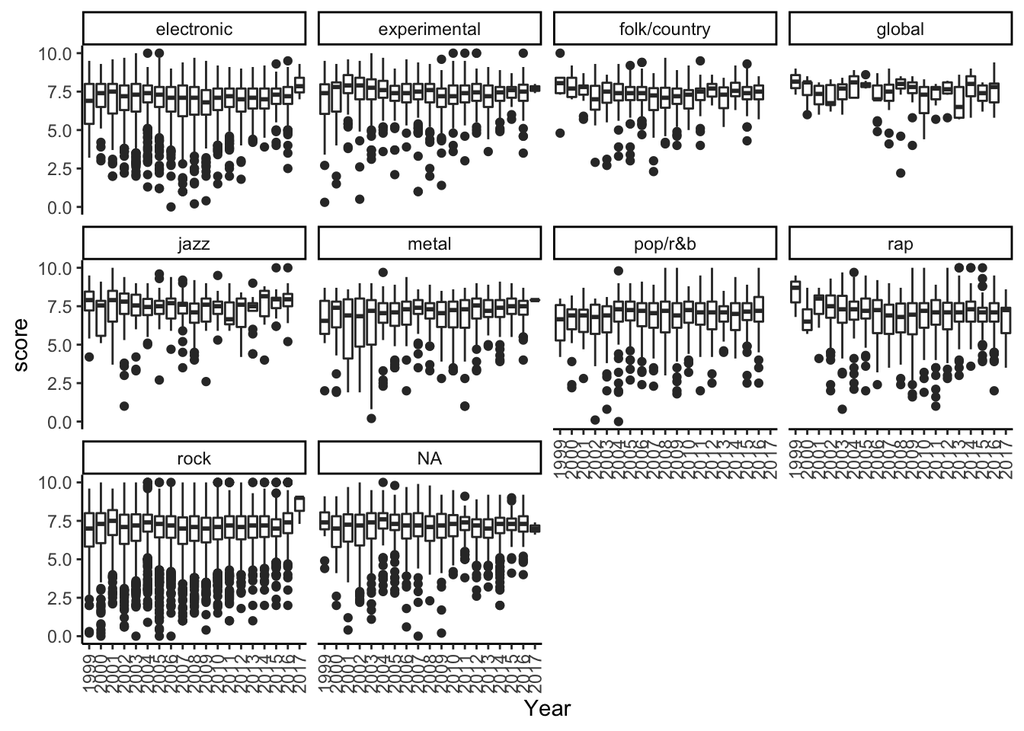

```r
pitchfork_dataset %>%
  ggplot(aes(x = as.factor(pub_year), y = score)) +
  geom_boxplot() +
  facet_wrap(~genre) + theme_classic() + theme(axis.text.x = element_text(angle = 90, vjust = 0.5, hjust=1)) + xlab("Year")
```

Since there were a lot of albums without a genre, I am going to remove those. I am also going to drop albums that span multiple genres (they will combine too many unique genres that will be hard to test) or are reissues of the same album. This will simplify the dataset so we can look for overall trends.

```r
pitchfork_dataset_clean <-
  pitchfork_dataset %>%
  drop_na(genre) %>% # drop those without a genre
  select(reviews_reviewid,title, score, best_new_music,  best_new_music, author, pub_year, artist, genre ) %>%
  distinct() %>%
  group_by(reviews_reviewid) %>%
  nest() %>%
  ungroup() %>%
  mutate(num = map_int(data, nrow)) %>%
  filter(num == 1) %>% # limit to one record per review. This is needed in cases of multiple genres. For simplicity, i will only use single genre albums
  unnest(data)
```

Now I am going to build models to compare them using AICc scores. I am building a complex one that compares different genres, different slopes for each year, and using the author (critic) as a random effect in case there are biases. I will compare that complex model down to one that has no predictors to see if any are necessary.

```r
library(lme4) # for models
m_interaction <- lmer((score) ~ genre*scale(pub_year) + (1|author), data =  pitchfork_dataset_clean)
m_additive <- lmer((score) ~ genre + scale(pub_year) + (1|author), data =  pitchfork_dataset_clean)
m_genre <- lmer((score) ~ genre  + (1|author), data =  pitchfork_dataset_clean)
m_year <- lmer((score) ~  scale(pub_year) + (1|author), data =  pitchfork_dataset_clean)
m_null <- lmer((score) ~ 1 + (1|author), data =  pitchfork_dataset_clean)

m_interaction_no_author <- lm((score) ~ genre*scale(pub_year), data =  pitchfork_dataset_clean)
```

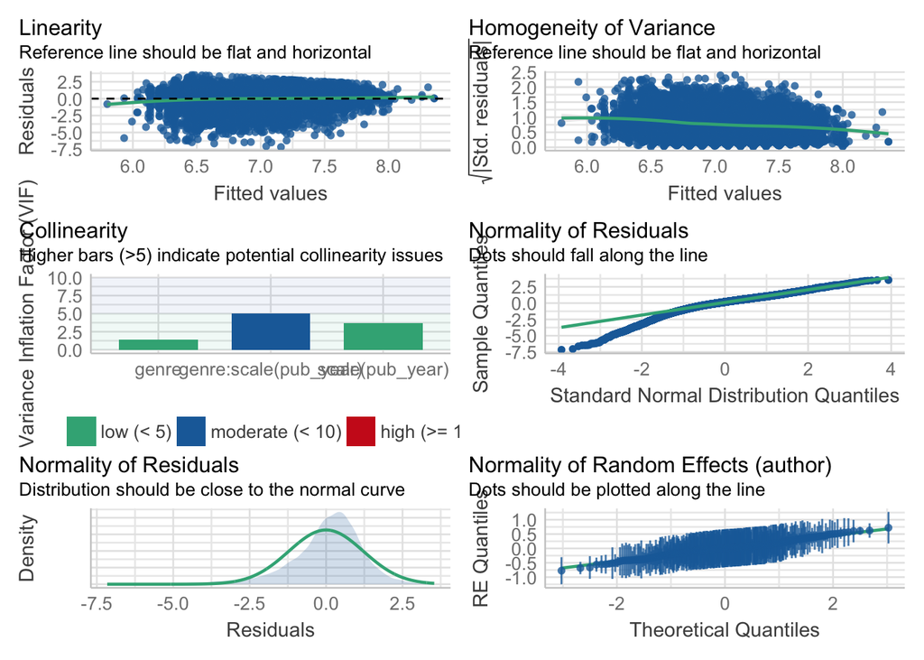

```r
library(performance) # checking assumptions
check_model(m_interaction)
```

```r
# using performance package
compare_performance(m_interaction, m_additive,m_genre, m_year, m_null )
```

```
## # Comparison of Model Performance Indices
##
## Name          |   Model |       AIC | AIC weights |      AICc | AICc weights |       BIC | BIC weights | R2 (cond.) | R2 (marg.) |   ICC |  RMSE | Sigma
## --------------------------------------------------------------------------------------------------------------------------------------------------------
## m_interaction | lmerMod | 39286.999 |       1.000 | 39287.069 |        1.000 | 39434.787 |     < 0.001 |      0.091 |      0.017 | 0.075 | 1.223 | 1.233
## m_additive    | lmerMod | 39304.343 |     < 0.001 | 39304.369 |      < 0.001 | 39393.016 |     < 0.001 |      0.089 |      0.014 | 0.076 | 1.225 | 1.234
## m_genre       | lmerMod | 39352.988 |     < 0.001 | 39353.010 |      < 0.001 | 39434.271 |     < 0.001 |      0.083 |      0.006 | 0.078 | 1.227 | 1.236
## m_year        | lmerMod | 39349.263 |     < 0.001 | 39349.266 |      < 0.001 | 39378.821 |       0.999 |      0.089 |      0.009 | 0.081 | 1.227 | 1.236
## m_null        | lmerMod | 39401.126 |     < 0.001 | 39401.128 |      < 0.001 | 39423.294 |     < 0.001 |      0.084 |      0.000 | 0.084 | 1.229 | 1.239
```

```r
# testing for random effects
lmerTest::ranova(m_interaction)
```

```
## ANOVA-like table for random-effects: Single term deletions
##
## Model:
## (score) ~ genre + scale(pub_year) + (1 | author) + genre:scale(pub_year)
##              npar logLik   AIC    LRT Df Pr(>Chisq)
## <none>         20 -19659 39357
## (1 | author)   19 -19906 39850 494.86  1  < 2.2e-16 ***
## ---
## Signif. codes:  0 '***' 0.001 '**' 0.01 '*' 0.05 '.' 0.1 ' ' 1
```

R-squared is rather low but better for random effect. Thus any statistical significance is explaining very little of the differences over time or by genre. But the author is significant as well as we can tell by the ANOVA-like table for random-effects.

```r
r2(m_interaction)
```

```
## # R2 for Mixed Models
##
##   Conditional R2: 0.091
##      Marginal R2: 0.017
```

```r
r2_nakagawa(m_interaction, by_group = TRUE)
```

```
## # Explained Variance by Level
##
## Level   |    R2
## ---------------
## Level 1 | 0.009
## author  | 0.124
```

```r
lmerTest::ranova(m_interaction)
```

```
## ANOVA-like table for random-effects: Single term deletions
##
## Model:
## (score) ~ genre + scale(pub_year) + (1 | author) + genre:scale(pub_year)
##              npar logLik   AIC    LRT Df Pr(>Chisq)
## <none>         20 -19659 39357
## (1 | author)   19 -19906 39850 494.86  1  < 2.2e-16 ***
## ---
## Signif. codes:  0 '***' 0.001 '**' 0.01 '*' 0.05 '.' 0.1 ' ' 1
```

Plotting the slopes for each genre over time. The majority of genres increase in their scores but it is noticable that rap doesn’t follow that trend. Metal makes the greatest increase over the the past two decades.

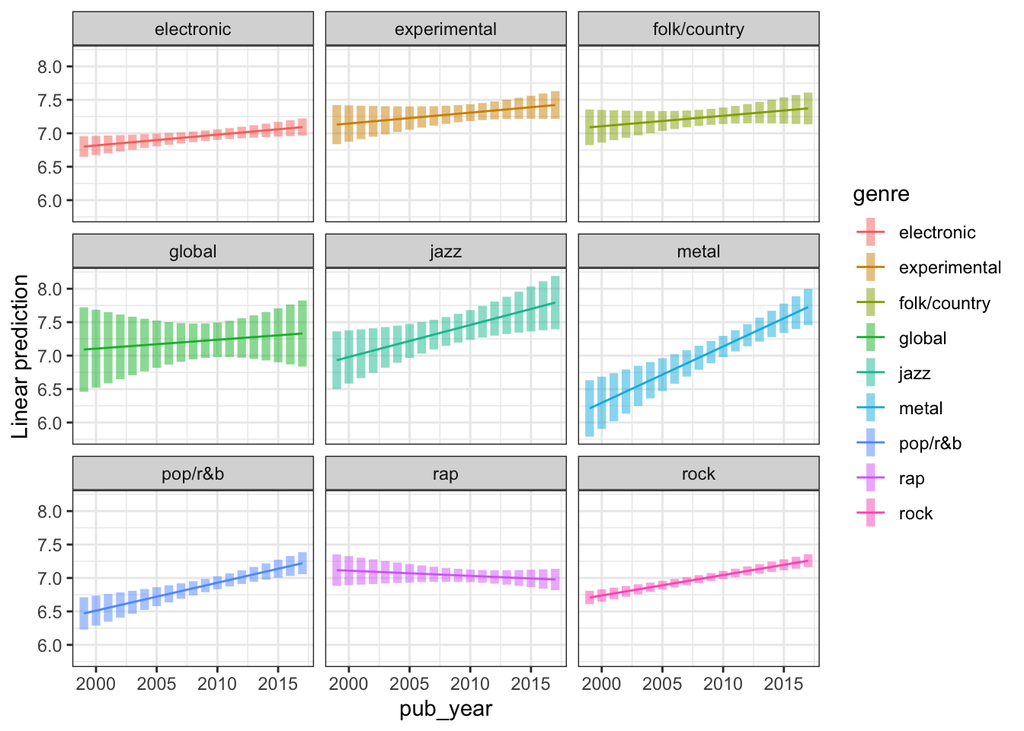

```r
library(emmeans)

# plot predictions for each genre
emmip(m_interaction, genre ~ scale(pub_year),
      cov.reduce = FALSE, CIs = TRUE) + facet_wrap(~genre) + theme_bw()
```

let’s dive in deeper on the metal data since that is the most interesting pattern. let’s filter our dataset just to metal albums. One thing I noticed initially was, there aren’t many reviews of metal albums in the early 2000s. I wonder how much of that is that most of that scene would’ve been the nu-metal era which was not highly respected by music critics in teh indie world.

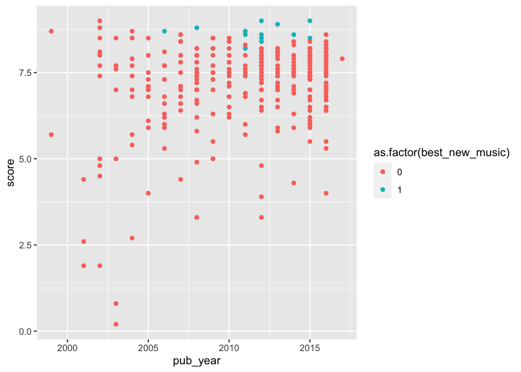

```r
metal_dataset <-
  pitchfork_dataset_clean %>%
  filter(genre == "metal")

# raw data of metal scores over the years.
metal_dataset %>%
  ggplot(aes(x = pub_year, y = score, color = as.factor(best_new_music))) + geom_point()
```

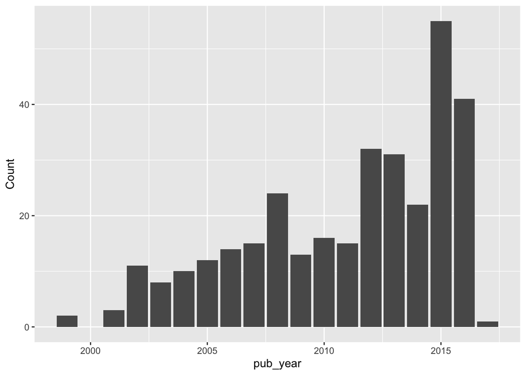

```r
metal_dataset %>%
  group_by(pub_year) %>%
  count(name = "Count") %>%
  ungroup() %>%
  ggplot(aes(x = pub_year, y = Count)) + geom_bar(stat = "identity")
```

Let’s see how this stacks up relative to other genres over the years. Fascinating, their reviews mostly focus on only electronic and rock music. Much better diversity of genres today.

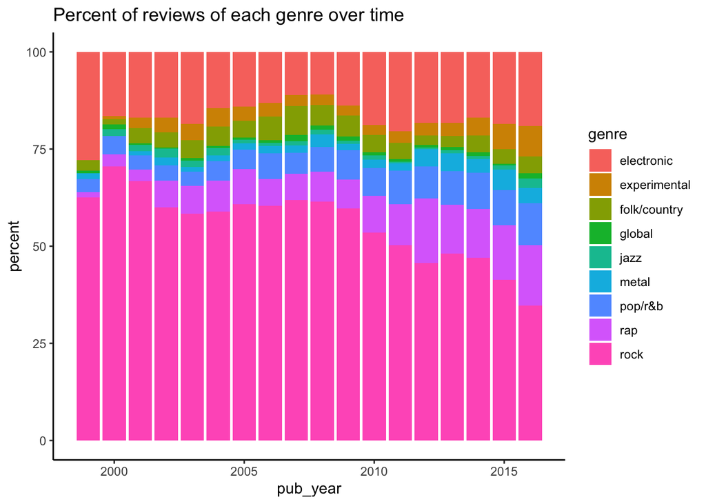

```r
pitchfork_dataset_clean %>%
  filter(pub_year < 2017) %>% # very little data when this dataset was compiled then
  group_by(genre, pub_year) %>%
  summarise(Count = n(), .groups = "drop") %>%
  group_by(pub_year) %>%
  mutate(percent = 100 * Count/sum(Count)) %>%
  ungroup() %>%
  ggplot(aes(x = pub_year, y =percent, fill = genre)) +
  geom_bar(stat = "identity") + theme_classic() + ggtitle("Percent of reviews of each genre over time")
```

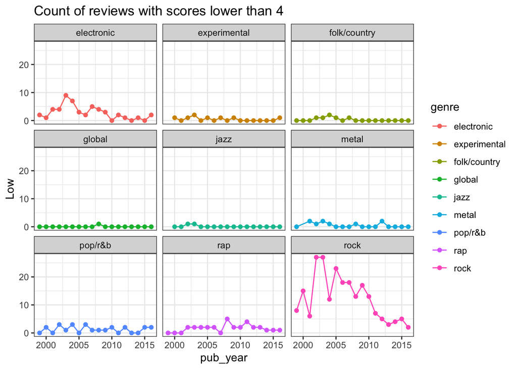

```r
low_scores <-
  pitchfork_dataset_clean %>%
  filter(pub_year < 2017) %>%
  mutate(low_score = case_when(score < 4 ~ "Low", TRUE ~ "Normal")) %>%
  group_by(genre, pub_year, low_score) %>%
  count() %>%
  ungroup() %>%
  pivot_wider(names_from = low_score, values_from = n, values_fill = 0) %>%
  mutate(Total = Low+Normal) %>%
  mutate(pecent_low = (100* Low / Total))

# not very informative due to the disparity in how many reviews they did for each genre
low_scores %>%
  ggplot(aes(x = pub_year, y = Low, color = genre, group = genre)) +
  geom_point() + geom_line() + facet_wrap(~genre) + theme_bw() + ggtitle("Count of reviews with scores lower than 4")
```

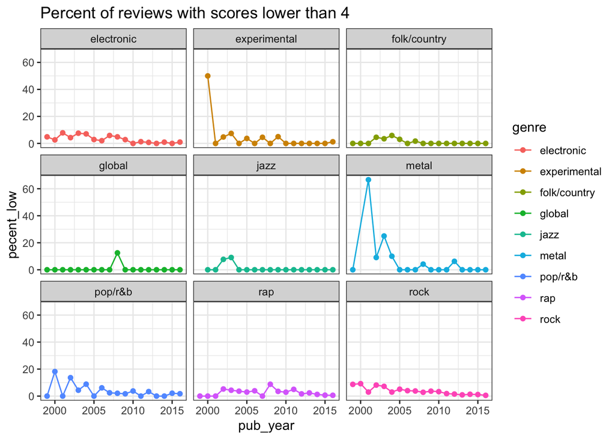

```r
# metal really jumps out when you look at the percent!
low_scores %>%
  ggplot(aes(x = pub_year, y = pecent_low, color = genre, group = genre)) +
  geom_point() + geom_line() + facet_wrap(~genre) + theme_bw() + ggtitle("Percent of reviews with scores lower than 4")
```

In conclusion, Pitchfork scores have slightly increased for most genres but most noticeably for metal albums. Also the number of albums from genres beyond their staple-electronic and rock music, has increased over time. Finally, when they did review other genres such as metal, they were very critical for the beginning of the 2000’s but have ceased to give as many harsh reviews.